## You like and use this theme? Then support me. Just paypal.me/PhlowMedia :)

# Newsletter: Stay in Touch for Future Updates

If you are a webdesigner interested in Jekyll, the static website generator, this little newsletter is for you. I share tutorials, clever code snippets and information about my own Jekyll Themes called [*Feeling Responsive*](http://phlow.github.io/feeling-responsive/) and [*Simplicity*](http://phlow.github.io/simplicity/). Please don’t expect weekly emails :)

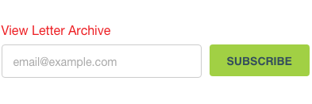

[figure not shown]

## A Responsive Jekyll Theme: *Feeling Responsive*

Do you want to get to know *Feeling Responsive*? Than check it out first and have a look on its home at http://phlow.github.io/feeling-responsive/.

To get to know *Feeling Responsive* check out all the features explained in the [documentation](http://phlow.github.io/feeling-responsive/documentation/).

And what license is *Feeling Responsive* released under? [This one](https://github.com/Phlow/feeling-responsive/blob/gh-pages/LICENSE).

## Why use this theme?

Feeling Responsive is heavily customizable.

1. Language-Support :)
2. Optimized for speed and it’s responsive.
3. Built on Foundation Framework.
4. Six different Headers.
5. Customizable navigation, footer,…

**[More ›](http://phlow.github.io/feeling-responsive/info/)**

## Changelog

*Feeling Responsive* is in active development. Thank you to everyone who contributed, especially [Róbert Papp](https://github.com/TWiStErRob), [Alexandra von Criegern](https://github.com/plutonik-a) and [Juan Jose Amor Iglesias](https://github.com/jjamor).

**[Read Changelog ›](https://phlow.github.io/feeling-responsive/changelog/)**

## Video Tutorial

Click the image to [watch the YouTube-Video-Tutorial](https://www.youtube.com/watch?v=rLS-BEvlEyY).

[figure not shown]